# Stat341 Portfolio

Brea Koenes

10/19/2022

# Chapter 4

## 4.5

#### Kimya Beta(1, 2)

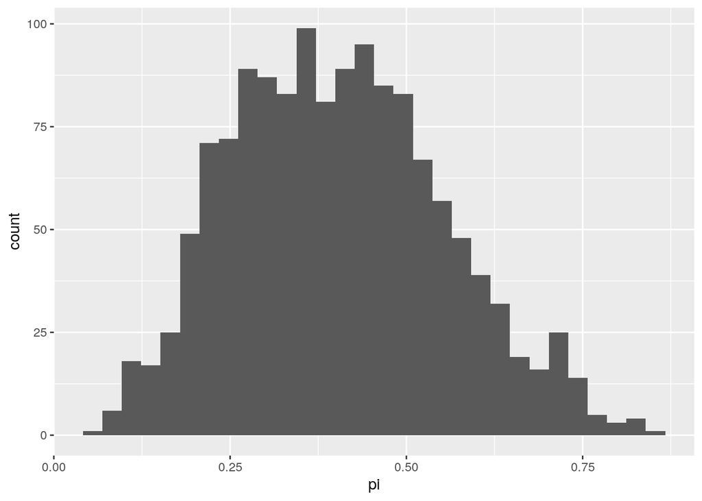

```r
set.seed(84735)
kimya_sim <- data.frame(pi = rbeta(10000, 1, 2)) |>
  mutate(y = rbinom(10000, size = 7, prob = pi))

kimya_posterior <- kimya_sim |>
  filter(y == 3)

ggplot(kimya_posterior, aes(x = pi)) +
  geom_histogram()
```

```r
kimya_posterior |>
  summarize(mean(pi), sd(pi))
```

| mean(pi) | sd(pi) |
| --- | --- |
| 0.4034074 | 0.1499301 |

#### Fernando Beta(0.5, 1)

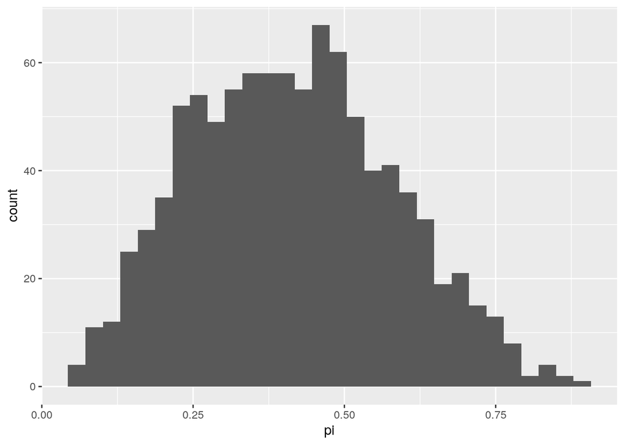

```r
set.seed(84735)
Fernando_sim <- data.frame(pi = rbeta(10000, 0.5, 1)) |>
  mutate(y = rbinom(10000, size = 7, prob = pi))

Fernando_posterior <- Fernando_sim |>
  filter(y == 3)

ggplot(Fernando_posterior, aes(x = pi)) +
  geom_histogram()
```

```r
Fernando_posterior |>
  summarize(mean(pi), sd(pi))
```

| mean(pi) | sd(pi) |
| --- | --- |
| 0.4140852 | 0.1653217 |

#### Ciara Beta(3, 10)

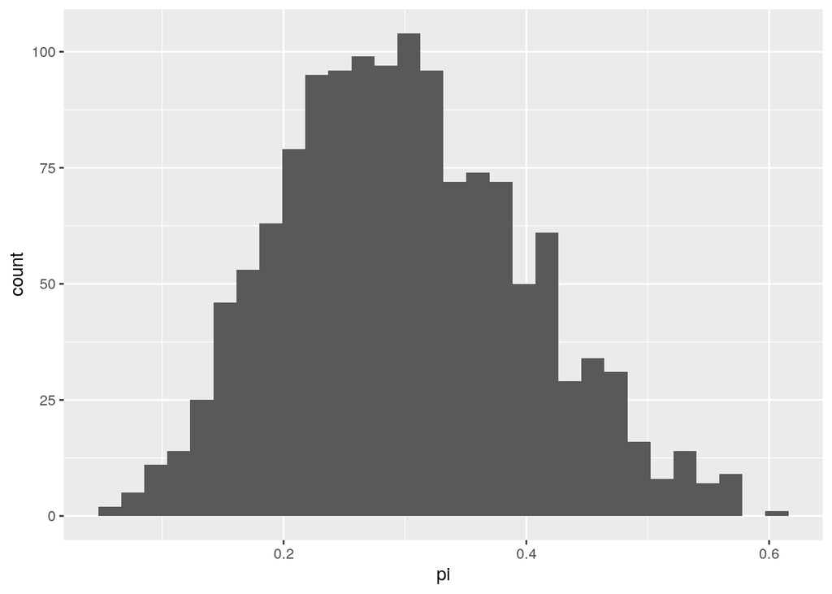

```r
set.seed(84735)
Ciara_sim <- data.frame(pi = rbeta(10000, 3, 10)) |>
  mutate(y = rbinom(10000, size = 7, prob = pi))

Ciara_posterior <- Ciara_sim |>
  filter(y == 3)

ggplot(Ciara_posterior, aes(x = pi)) +
  geom_histogram()
```

```r
Ciara_posterior |>
  summarize(mean(pi), sd(pi))
```

| mean(pi) | sd(pi) |
| --- | --- |
| 0.2993225 | 0.09979088 |

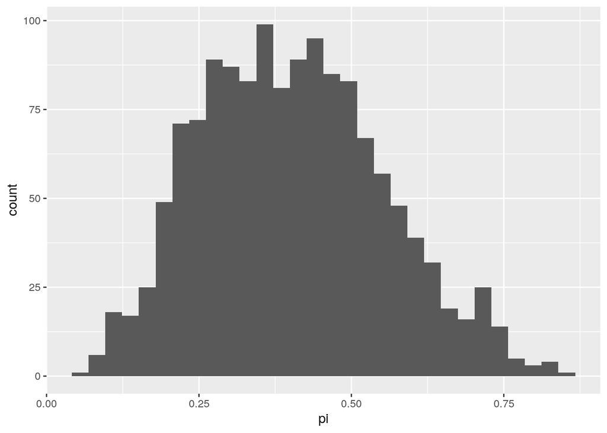

```r
set.seed(84735)
Taylor_sim <- data.frame(pi = rbeta(10000, 1, 2)) |>
  mutate(y = rbinom(10000, size = 7, prob = pi))

Taylor_posterior <- Taylor_sim |>
  filter(y == 3)

ggplot(Taylor_posterior, aes(x = pi)) +
  geom_histogram()
```

```r
Taylor_posterior |>
  summarize(mean(pi), sd(pi))
```

| mean(pi) | sd(pi) |
| --- | --- |
| 0.4034074 | 0.1499301 |

## 4.14

1. The posterior mode of pi as the weighted average of the prior mode and observed sample success rate:

$$
$$\begin{align*}
Mode(\pi∣Y=y) &= \frac{\alpha+y−1}{\alpha+\beta+n−2} \\
&= \frac{\alpha−1}{\alpha+\beta+n−2} + \frac{y}{\alpha+\beta+n−2} \\
&= \frac{\alpha−1}{\alpha+\beta+n−2} ⋅
\frac{\alpha+\beta−2}{\alpha+\beta−2} + \frac{y}{\alpha+\beta+n−2} ⋅
\frac{n}{n} \\
&= \frac{\alpha+\beta−2}{\alpha+\beta+n−2} ⋅
\frac{\alpha−1}{\alpha+\beta−2} + \frac{n}{\alpha+\beta+n−2} ⋅
\frac{y}{n} \\
&= \frac{\alpha+\beta−2}{\alpha+\beta+n−2} ⋅ Mode(\pi) +
\frac{n}{\alpha+\beta+n−2} ⋅ \frac{y}{n} \\
\end{align*}$$
$$

# Chapter 5

## 5.10

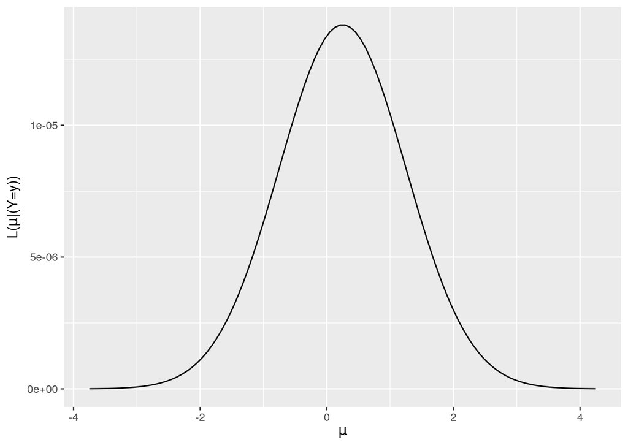

```r
data <- c(-0.7,1.2,4.5,-4)
plot_normal_likelihood(y = data, sigma = 2)
```

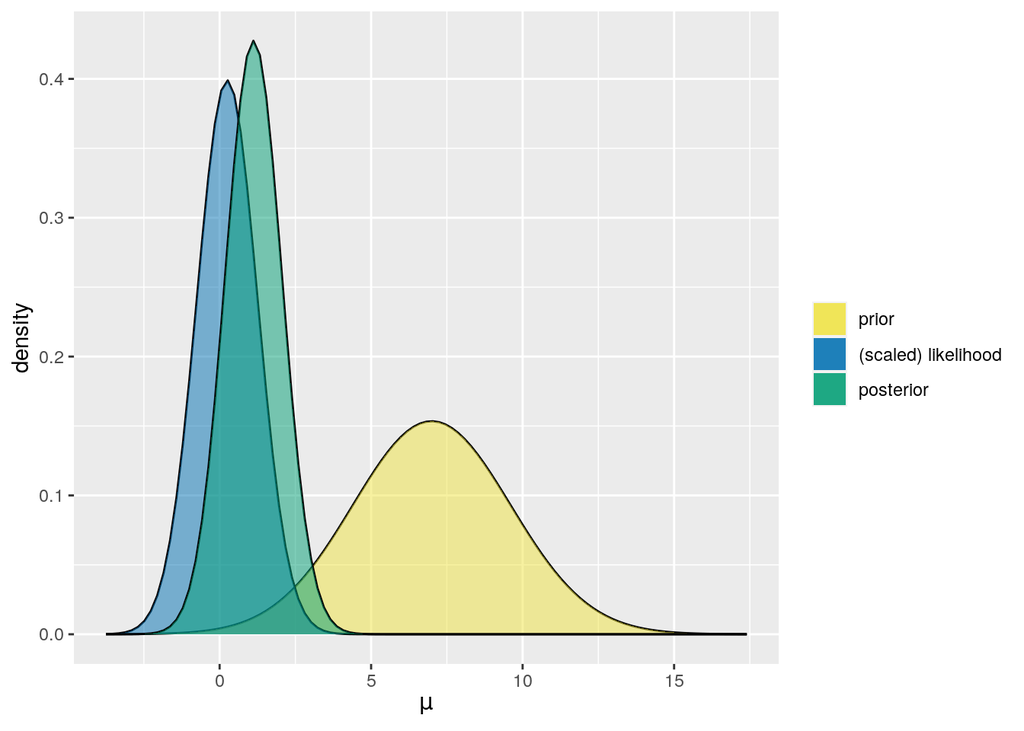

```r
plot_normal_normal(mean = 7, sd = 2.6, sigma = 2, y_bar = .25, n = 4)
```

```r
bayesrules::summarize_beta(alpha = 2, beta = 7)
```

| mean | mode | var | sd |
| --- | --- | --- | --- |
| 0.2222222 | 0.1428571 | 0.01728395 | 0.1314684 |

```r
summarize_normal_normal(mean = 7, sd = 2.6, sigma = 2, y_bar = .25, n = 4)
```

| model | mean | mode | var | sd |
| --- | --- | --- | --- | --- |
| prior | 7.000000 | 7.000000 | 6.760000 | 2.6000000 |
| posterior | 1.119845 | 1.119845 | 0.871134 | 0.9333456 |

```r
pnorm(0, mean=7,sd=2, log.p=FALSE)
```

```
## [1] 0.0002326291
```

```r
pnorm(8, mean=7,sd=2, log.p=FALSE)
```

```
## [1] 0.6914625
```

## 5.11

```r
summarize_normal_normal(mean = 80, sd = 4, sigma = 3, y_bar = 86, n = 32)
```

| model | mean | mode | var | sd |
| --- | --- | --- | --- | --- |
| prior | 80.00000 | 80.00000 | 16.0000000 | 4.0000000 |
| posterior | 85.89635 | 85.89635 | 0.2763916 | 0.5257295 |

```r
summarize_normal_normal(mean = 80, sd = 4, sigma = 3, y_bar = 82, n = 32)
```

| model | mean | mode | var | sd |
| --- | --- | --- | --- | --- |
| prior | 80.00000 | 80.00000 | 16.0000000 | 4.0000000 |
| posterior | 81.96545 | 81.96545 | 0.2763916 | 0.5257295 |

```r
summarize_normal_normal(mean = 80, sd = 4, sigma = 3, y_bar = 84, n = 32)
```

| model | mean | mode | var | sd |
| --- | --- | --- | --- | --- |
| prior | 80.0000 | 80.0000 | 16.0000000 | 4.0000000 |
| posterior | 83.9309 | 83.9309 | 0.2763916 | 0.5257295 |

## 5.13

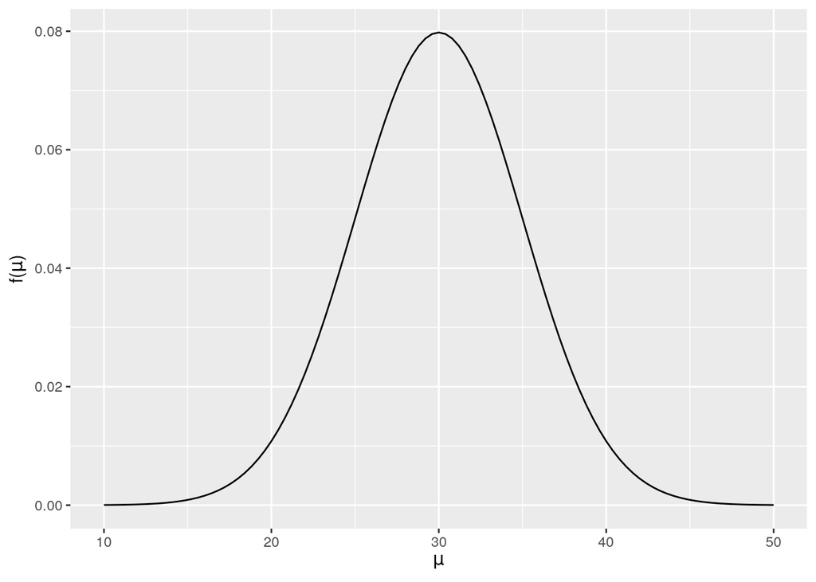

```r
plot_normal(mean = 30, sd = 5)
```

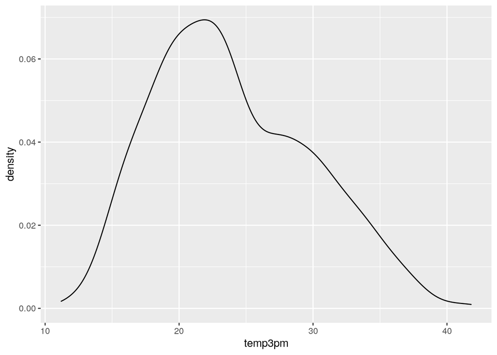

```r
ggplot(weather_perth, aes(x = temp3pm)) +
  geom_density()
```

```r
weather_perth |>
  summarize(mean(temp3pm))
```

| mean(temp3pm) |
| --- |
| 24.0009 |

```r
summarize_normal_normal(mean = 30, sd = 5, sigma = 3,
                        y_bar = 24, n = 1000)
```

| model | mean | mode | var | sd |
| --- | --- | --- | --- | --- |
| prior | 30.00000 | 30.00000 | 25.000000000 | 5.00000000 |
| posterior | 24.00216 | 24.00216 | 0.008996761 | 0.09485126 |

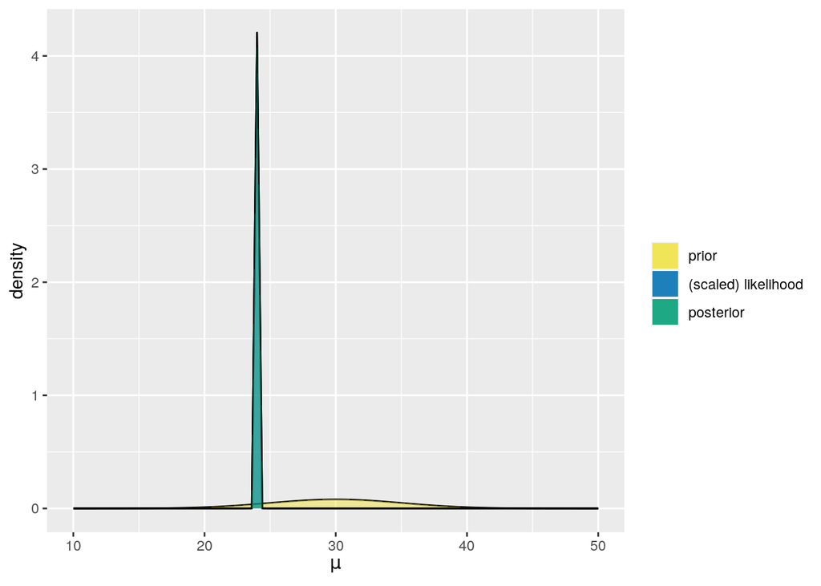

```r
plot_normal_normal(mean = 30, sd = 5, sigma = 3,
                   y_bar = 24, n = 1000)
```

Given the prior, I originally thought that the average temperature is around 30 degrees Celsius. However, there was uncertainty in that prior since it could be anywhere from 10 to 50 degrees. Due to this uncertainty, I was not surprised to see that the posterior is centered around 24.